# **NN, PINN, and BPINN for Linear Inverse Imaging with Gaussian PSF**

A teaching‑oriented notebook with theory, equations, algorithms, and runnable PyTorch code._

**Ali Mohammad-Djafari**

** November 2025**

*All rights reserved*

## Contents

1. Problem setup and forward model (g = H f + \varepsilon)
2. Synthetic dataset generator (Gaussian PSF via FFT convolution)
3. U‑Net baseline (NN): data loss only
4. PINN: data + physics loss
5. BPINN: data + physics + prior (TV, H1, Laplacian, RKHS, Mean‑image)
6. MC‑Dropout for predictive uncertainty
7. Training loops, diagnostics, grayscale figures, model saving/loading
8. Quick demo (CPU‑friendly), ablations
9. References

## 1. Problem setup

We consider the linear model $ g = H f + \varepsilon $ where $H$ is a Gaussian blur, for example the approximate model for heat diffusion.

This model can be extended to any other model, by changing the forward operator.

The Python program below consider the Objectives: $$ \mathcal{J}_\text{NN}=\alpha\,\| \hat f - f_T\|^2,\quad \mathcal{J}_\text{PINN}=\alpha\,\| \hat f - f_T\|^2 + \beta\,\|H\hat f - g_T\|^2,\quad \mathcal{J}_\text{BPINN}=\alpha\,\| \hat f - f_T\|^2 + \beta\,\|H\hat f - g_T\|^2 + \gamma\,\mathcal{L}_\text{prior}. $$ By choosing appropriately $\alpha$, $\beta$ and $\gamma$, we can choose, for example NN (1,0,0), PINN (1,.5,0), and BPINN (1,.5,.1).

## 2. Imports & setup

```python
import os, math, random, json
from pathlib import Path
import numpy as np
import torch, torch.nn as nn, torch.nn.functional as F
from torch.utils.data import DataLoader, Dataset
import matplotlib.pyplot as plt

def set_seed(seed=42):
    random.seed(seed); np.random.seed(seed); torch.manual_seed(seed)

device = torch.device("cuda" if torch.cuda.is_available() else "cpu")
print("Using device:", device)

data_dir = Path("../data"); data_dir.mkdir(parents=True, exist_ok=True)
out_dir = Path("../output"); out_dir.mkdir(parents=True, exist_ok=True)
ckpt_dir = Path("../checkpoints"); ckpt_dir.mkdir(parents=True, exist_ok=True)
```

```
Using device: cuda
```

## 3. Forward model and dataset

Gaussian PSF via FFT convolution. Synthetic shapes form $$ \left\{f_{Ti}, g_{Ti}\right\} \quad \mbox{with}\quad g_{Ti} = H f_{Ti} + \varepsilon_i $$

```
 Show 4 samples of training data
```

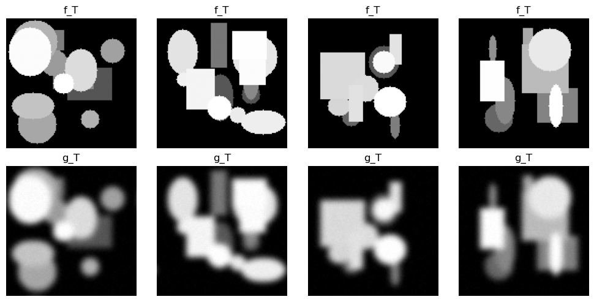

```
 Show 4 samples of Validation data
```

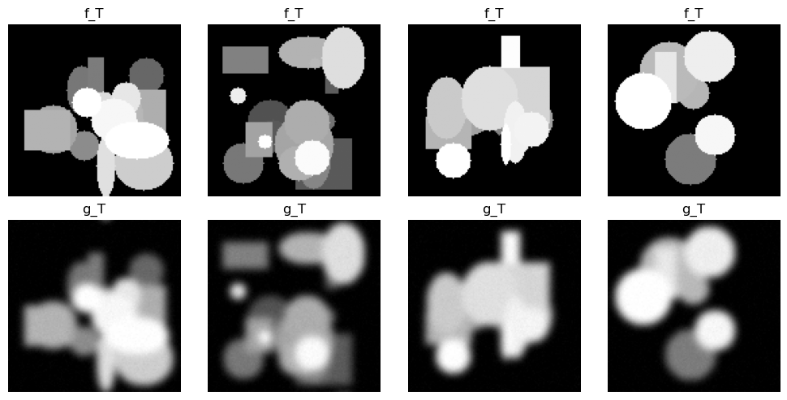

```
 Show 4 samples of Test data
```

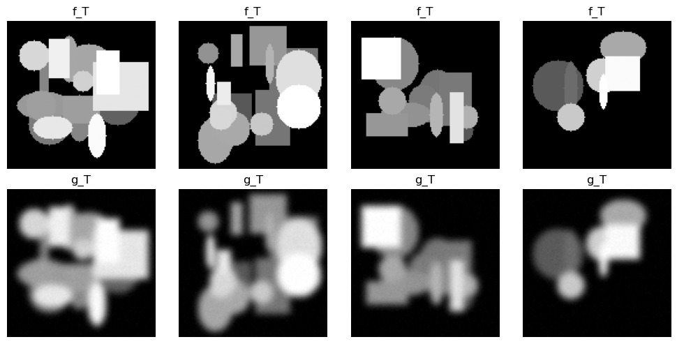

```python
import numpy as np
import torch

def gaussian_psf(size=15, sigma=3.0):
    ax = np.arange(-size//2+1., size//2+1.)
    xx, yy = np.meshgrid(ax, ax)
    k = np.exp(-(xx**2+yy**2)/(2*sigma**2)).astype(np.float32)
    k /= (k.sum() + 1e-12)
    return k

def conv2d_fft(x, k):
    import torch.fft as tfft
    N, C, H, W = x.shape
    K = torch.from_numpy(k).to(x.device)
    # Pad kernel to image size
    Kpad = torch.zeros((H, W), device=x.device, dtype=x.dtype)
    kh, kw = K.shape
    kh = min(kh, H); kw = min(kw, W)
    Kpad[:kh, :kw] = K[:kh, :kw]
    # IMPORTANT: center the PSF in Fourier domain (align impulse to [0,0])
    # This is equivalent to fftshift on the spatial kernel before FFT.
    Kpad = torch.roll(Kpad, shifts=(-kh//2+1, -kw//2+1), dims=(0, 1))

    Xf = tfft.fft2(x, dim=(-2, -1))
    Kf = tfft.fft2(Kpad)
    y  = tfft.ifft2(Xf * Kf, dim=(-2, -1)).real
    return y

def forward_linear(f_t, psf, downsample=1, noise_sigma=0.01):
    g = conv2d_fft(f_t, psf)
    if downsample > 1:
        g = F.avg_pool2d(g, downsample, downsample)
    if noise_sigma > 0:
        g = g + noise_sigma * torch.randn_like(g)
    return torch.clamp(g, 0.0, 1.0)

class ShapesDataset(Dataset):
    def __init__(self, n=128, img_size=128, psf=None, noise_sigma=0.01, downsample=1, seed=0):
        self.n, self.img_size = n, img_size
        self.psf = psf if psf is not None else gaussian_psf(15, 3.0)
        self.noise_sigma, self.down = noise_sigma, downsample
        self.rng = np.random.default_rng(seed)
    def __len__(self): return self.n
    def _rand_shape(self, H, W):
        canvas = np.zeros((H,W), np.float32)
        Y, X = np.ogrid[:H, :W]
        for _ in range(self.rng.integers(5,20)):
            typ = self.rng.choice(['circle','ellipse','rect'])
            val = float(self.rng.uniform(0.3,1.0))
            cx, cy = self.rng.integers(W//6,5*W//6,size=2)
            sx, sy = self.rng.integers(W//32,W//5), self.rng.integers(H//12,H//5)
            if typ=='circle':
                r = min(sx,sy); mask = (X-cx)**2 + (Y-cy)**2 <= r*r
            elif typ=='ellipse':
                mask = ((X-cx)**2)/(sx*sx+1e-6) + ((Y-cy)**2)/(sy*sy+1e-6) <= 1.0
            else:
                mask = np.zeros((H,W), bool)
                x0,x1=max(0,cx-sx),min(W,cx+sx); y0,y1=max(0,cy-sy),min(H,cy+sy); mask[y0:y1,x0:x1]=True
            canvas[mask] = np.maximum(canvas[mask], val)
        m, M = canvas.min(), canvas.max()
        return (canvas-m)/(M-m+1e-8)
    def __getitem__(self, idx):
        H=W=self.img_size
        f = self._rand_shape(H,W).astype(np.float32)
        f_t = torch.from_numpy(f[None,None])
        g_t = forward_linear(f_t, self.psf, self.down, self.noise_sigma)
        return f_t.squeeze(0), g_t.squeeze(0)

# quick preview
psf = gaussian_psf(15, 3.0)
train_ds = ShapesDataset(n=128, img_size=128, psf=psf, noise_sigma=0.01, seed=1)
val_ds   = ShapesDataset(n=32, img_size=128, psf=psf, noise_sigma=0.01, seed=2)
test_ds  = ShapesDataset(n=32, img_size=128, psf=psf, noise_sigma=0.01, seed=3)

#np.savez_compressed(f"{data_dir}/train_data.npz", train_ds)
#np.savez_compressed(f"{data_dir}/val_data.npz", val_ds)
#np.savez_compressed(f"{data_dir}/test_data.npz", test_ds)

print(" Show 4 samples of training data ")
from torch.utils.data import DataLoader
f_t, g_t = next(iter(DataLoader(train_ds, batch_size=4)))
import matplotlib.pyplot as plt
fig, axs = plt.subplots(2,4, figsize=(10,5))
for i in range(4):
    axs[0,i].imshow(f_t[i,0], vmin=0, vmax=1, cmap='gray'); axs[0,i].set_title("f_T"); axs[0,i].axis('off')
    axs[1,i].imshow(g_t[i,0], vmin=0, vmax=1, cmap='gray'); axs[1,i].set_title("g_T"); axs[1,i].axis('off')
plt.tight_layout();
plt.savefig(f"{out_dir}/Training_dataset.png", dpi=140);
plt.show()

print(" Show 4 samples of Validation data ")
from torch.utils.data import DataLoader
f_t, g_t = next(iter(DataLoader(val_ds, batch_size=4)))
import matplotlib.pyplot as plt
fig, axs = plt.subplots(2,4, figsize=(10,5))
for i in range(4):
    axs[0,i].imshow(f_t[i,0], vmin=0, vmax=1, cmap='gray'); axs[0,i].set_title("f_T"); axs[0,i].axis('off')
    axs[1,i].imshow(g_t[i,0], vmin=0, vmax=1, cmap='gray'); axs[1,i].set_title("g_T"); axs[1,i].axis('off')
plt.tight_layout();
plt.savefig(f"{out_dir}/Validation_dataset.png", dpi=140);
plt.show()

print(" Show 4 samples of Test data ")
from torch.utils.data import DataLoader
f_t, g_t = next(iter(DataLoader(test_ds, batch_size=4)))
import matplotlib.pyplot as plt
fig, axs = plt.subplots(2,4, figsize=(10,5))
for i in range(4):
    axs[0,i].imshow(f_t[i,0], vmin=0, vmax=1, cmap='gray'); axs[0,i].set_title("f_T"); axs[0,i].axis('off')
    axs[1,i].imshow(g_t[i,0], vmin=0, vmax=1, cmap='gray'); axs[1,i].set_title("g_T"); axs[1,i].axis('off')
plt.tight_layout();
plt.savefig(f"{out_dir}/Test_dataset.png", dpi=140);
plt.show()
```

## 3. Priors and metrics

Different prior modeling has been proposed:

Total Variation (TV), Semi-Norme $H^1$, Laplacian, and RKHS (spectral) priors;

PSNR/SSIM metrics.

```python
def tv_iso(x, eps=1e-6):
    dx = x[:,:,:,1:] - x[:,:,:,:-1]
    dy = x[:,:,1:,:] - x[:,:,:-1,:]
    dx_c = dx[:,:,:-1,:]; dy_c = dy[:,:,:,:-1]
    return torch.sqrt(dx_c*dx_c + dy_c*dy_c + eps).mean()

def h1_seminorm(x):
    dx = x[:,:,:,1:] - x[:,:,:,:-1]
    dy = x[:,:,1:,:] - x[:,:,:-1,:]
    return dx.pow(2).mean() + dy.pow(2).mean()

def laplacian_l2(x):
    w = torch.tensor([[0,1,0],[1,-4,1],[0,1,0]], dtype=x.dtype, device=x.device)[None,None]
    y = F.conv2d(x, w, padding=1)
    return y.pow(2).mean()

def rkhs_spectral(x, s=1.0, lam=1e-2):
    import torch.fft as tfft
    X = tfft.fft2(x, dim=(-2,-1))
    N,C,H,W = x.shape
    ky = torch.fft.fftfreq(H, d=1.0).to(x.device).reshape(1,1,H,1)
    kx = torch.fft.fftfreq(W, d=1.0).to(x.device).reshape(1,1,1,W)
    k2 = (kx**2 + ky**2)
    w  = (1.0 + lam*k2)**s
    return (w*(X.real**2 + X.imag**2)).mean()

def prior_term(x, prior='tv', gamma=5e-4, rkhs_s=1.0, rkhs_lambda=1e-2, f_bar=None):
    if prior=='mean':
        if f_bar is None: raise ValueError("Need f_bar for mean prior")
        return gamma * F.mse_loss(x, f_bar.expand_as(x))
    if prior in ('tv','tv_iso'): return gamma * tv_iso(x)
    if prior=='h1':              return gamma * h1_seminorm(x)
    if prior in ('lap','laplacian'): return gamma * laplacian_l2(x)
    if prior=='rkhs':            return gamma * rkhs_spectral(x, s=rkhs_s, lam=rkhs_lambda)
    return 0.0 * x.mean()

def psnr(pred, gt, data_range=1.0):
    mse = torch.mean((pred-gt)**2).item()
    if mse==0: return 99.0
    return 20*np.log10(data_range) - 10*np.log10(mse)

def ssim_torch(img1, img2, data_range=1.0, K1=0.01, K2=0.03, win=7):
    C1=(K1*data_range)**2; C2=(K2*data_range)**2; pad=win//2
    mu1=F.avg_pool2d(img1,win,1,pad); mu2=F.avg_pool2d(img2,win,1,pad)
    s1 =F.avg_pool2d(img1*img1,win,1,pad)-mu1*mu1
    s2 =F.avg_pool2d(img2*img2,win,1,pad)-mu2*mu2
    s12=F.avg_pool2d(img1*img2,win,1,pad)-mu1*mu2
    m=((2*mu1*mu2+C1)*(2*s12+C2))/((mu1*mu1+mu2*mu2+C1)*(s1+s2+C2))
    return m.mean().item()
```

## 4. U‑Net (with dropout)

```python
class DoubleConv(nn.Module):
    def __init__(self, in_ch, out_ch, p_drop=0.1):
        super().__init__()
        self.seq = nn.Sequential(
            nn.Conv2d(in_ch, out_ch, 3, padding=1), nn.ReLU(True), nn.Dropout2d(p=p_drop),
            nn.Conv2d(out_ch, out_ch, 3, padding=1), nn.ReLU(True)
        )
    def forward(self, x): return self.seq(x)

class UNet(nn.Module):
    def __init__(self, base_ch=24, p_drop=0.1):
        super().__init__()
        self.inc   = DoubleConv(1, base_ch, p_drop)
        self.down1 = nn.Sequential(nn.MaxPool2d(2), DoubleConv(base_ch, base_ch*2, p_drop))
        self.down2 = nn.Sequential(nn.MaxPool2d(2), DoubleConv(base_ch*2, base_ch*4, p_drop))
        self.up1   = nn.ConvTranspose2d(base_ch*4, base_ch*2, 2, stride=2)
        self.conv1 = DoubleConv(base_ch*4, base_ch*2, p_drop)
        self.up2   = nn.ConvTranspose2d(base_ch*2, base_ch, 2, stride=2)
        self.conv2 = DoubleConv(base_ch*2, base_ch, p_drop)
        self.outc  = nn.Conv2d(base_ch, 1, 1)
    def forward(self, x):
        x1 = self.inc(x); x2 = self.down1(x1); x3 = self.down2(x2)
        x  = self.up1(x3); x = torch.cat([x, x2], 1); x = self.conv1(x)
        x  = self.up2(x);  x = torch.cat([x, x1], 1); x = self.conv2(x)
        return torch.sigmoid(self.outc(x))
```

## 5. Training & evaluation loops (Algorithms)

```python
def physics_forward(f_pred, psf, downsample=1):
    return forward_linear(f_pred, psf, downsample, noise_sigma=0.0)

class EMANorm:
    def __init__(self, momentum=0.98, eps=1e-8):
        self.m = momentum
        self.eps = eps
        self.val = None
    def __call__(self, x: torch.Tensor):
        v = x.detach().mean()
        if self.val is None:
            self.val = v
        else:
            self.val = self.m * self.val + (1 - self.m) * v
        return x / (self.val + self.eps)

def linear_warmup(epoch, warm_epochs, target):
    if warm_epochs <= 0: return target
    return target * min(1.0, epoch / float(warm_epochs))

def train_one_epoch(model, opt, loader, mode, alpha, beta, gamma, psf, down, norm_phys=True, prior='tv', rkhs_s=1.0, rkhs_lambda=1e-2, f_bar=None):
    model.train(); L=[]
    for f_t, g_t in loader:
        f_t, g_t = f_t.to(device), g_t.to(device)
        opt.zero_grad()
        f_pred = model(g_t)
        loss = alpha * F.mse_loss(f_pred, f_t)
        if mode in ('PINN','BPINN'):
            g_hat = physics_forward(f_pred, psf=psf, downsample=down)
            phys = F.mse_loss(g_hat, g_t)
            if norm_phys: phys = phys / (g_t.pow(2).mean().detach()+1e-8)
            loss = loss + beta * phys
        if mode=='BPINN':
            loss = loss + prior_term(f_pred, prior=prior, gamma=gamma, rkhs_s=rkhs_s, rkhs_lambda=rkhs_lambda, f_bar=f_bar)
        loss.backward(); opt.step(); L.append(loss.item())
    return float(np.mean(L))

@torch.no_grad()
def evaluate(model, loader, mode, alpha, beta, gamma, psf, down, norm_phys=True, prior='tv', rkhs_s=1.0, rkhs_lambda=1e-2, f_bar=None):
    model.eval(); L=[]; P=[]; S=[]
    for f_t, g_t in loader:
        f_t, g_t = f_t.to(device), g_t.to(device)
        f_pred = model(g_t)
        loss = alpha * F.mse_loss(f_pred, f_t)
        if mode in ('PINN','BPINN'):
            g_hat = physics_forward(f_pred, psf=psf, downsample=down)
            phys = F.mse_loss(g_hat, g_t)
            if norm_phys: phys = phys / (g_t.pow(2).mean().detach()+1e-8)
            loss = loss + beta * phys
        if mode=='BPINN':
            loss = loss + prior_term(f_pred, prior=prior, gamma=gamma, rkhs_s=rkhs_s, rkhs_lambda=rkhs_lambda, f_bar=f_bar)
        L.append(loss.item()); P.append(psnr(f_pred, f_t)); S.append(ssim_torch(f_pred, f_t))
    return float(np.mean(L)), float(np.mean(P)), float(np.mean(S))

@torch.enable_grad()
def mc_dropout_predict(net, g, T=16):
    net.train()
    S = []
    for _ in range(T):
        S.append(net(g).detach())
    stack = torch.stack(S, 0)
    return stack.mean(0), stack.var(0, unbiased=False)
```

## 6. Quick demo (CPU‑friendly)

Trains NN → PINN → BPINN with small datasets/epochs. Increase sizes for stronger results.

### Training :

Trains NN → PINN → BPINN with small datasets/epochs. Increase sizes for stronger results.

#### Load psf and data

```python
#### Load psf and data

set_seed(123)
psf = gaussian_psf(15, 3.0)
train_ds = ShapesDataset(n=128, img_size=128, psf=psf, noise_sigma=0.01, seed=10)
val_ds   = ShapesDataset(n=32, img_size=128, psf=psf, noise_sigma=0.01, seed=11)
test_ds  = ShapesDataset(n=32, img_size=128, psf=psf, noise_sigma=0.01, seed=12)

train_dl = DataLoader(train_ds, batch_size=8, shuffle=True, num_workers=0)
val_dl   = DataLoader(val_ds,   batch_size=8, shuffle=False, num_workers=0)
test_dl  = DataLoader(test_ds,  batch_size=8, shuffle=False, num_workers=0)
```

#### Saves the trained models to be loaded later for testing

```
==> Training NN
[NN] e1: train 1.345e-01 | val 2.624e-02 | PSNR 15.85 | SSIM 0.687
[NN] e2: train 2.391e-02 | val 1.219e-02 | PSNR 19.14 | SSIM 0.706
[NN] e3: train 1.434e-02 | val 1.076e-02 | PSNR 19.68 | SSIM 0.797
[NN] e4: train 1.330e-02 | val 1.099e-02 | PSNR 19.59 | SSIM 0.803
[NN] e5: train 1.331e-02 | val 1.136e-02 | PSNR 19.46 | SSIM 0.798
[NN] e6: train 1.168e-02 | val 9.194e-03 | PSNR 20.38 | SSIM 0.812
[NN] e7: train 1.165e-02 | val 9.168e-03 | PSNR 20.38 | SSIM 0.819
[NN] e8: train 1.130e-02 | val 9.139e-03 | PSNR 20.40 | SSIM 0.814
[NN] e9: train 1.054e-02 | val 1.107e-02 | PSNR 19.57 | SSIM 0.810
[NN] e10: train 1.219e-02 | val 9.662e-03 | PSNR 20.16 | SSIM 0.814
[NN] e11: train 1.254e-02 | val 1.161e-02 | PSNR 19.37 | SSIM 0.800
[NN] e12: train 1.194e-02 | val 1.058e-02 | PSNR 19.76 | SSIM 0.805
[NN] e13: train 1.055e-02 | val 8.400e-03 | PSNR 20.76 | SSIM 0.826
[NN] e14: train 9.600e-03 | val 8.741e-03 | PSNR 20.60 | SSIM 0.819
[NN] e15: train 1.015e-02 | val 8.496e-03 | PSNR 20.71 | SSIM 0.826
[NN] e16: train 1.019e-02 | val 9.070e-03 | PSNR 20.43 | SSIM 0.819
[NN] e17: train 8.881e-03 | val 6.378e-03 | PSNR 21.99 | SSIM 0.846
[NN] e18: train 8.313e-03 | val 7.049e-03 | PSNR 21.53 | SSIM 0.859
[NN] e19: train 7.628e-03 | val 6.051e-03 | PSNR 22.19 | SSIM 0.867
[NN] e20: train 7.355e-03 | val 7.030e-03 | PSNR 21.54 | SSIM 0.860
[NN] e21: train 7.319e-03 | val 7.496e-03 | PSNR 21.29 | SSIM 0.871
[NN] e22: train 6.770e-03 | val 5.537e-03 | PSNR 22.60 | SSIM 0.866
[NN] e23: train 6.668e-03 | val 4.395e-03 | PSNR 23.59 | SSIM 0.887
[NN] e24: train 6.602e-03 | val 5.887e-03 | PSNR 22.30 | SSIM 0.882
[NN] e25: train 6.649e-03 | val 4.791e-03 | PSNR 23.20 | SSIM 0.888
[NN] e26: train 6.214e-03 | val 4.283e-03 | PSNR 23.71 | SSIM 0.890
[NN] e27: train 6.348e-03 | val 5.394e-03 | PSNR 22.70 | SSIM 0.900
[NN] e28: train 5.702e-03 | val 3.756e-03 | PSNR 24.25 | SSIM 0.900
[NN] e29: train 5.548e-03 | val 4.236e-03 | PSNR 23.74 | SSIM 0.898
[NN] e30: train 5.566e-03 | val 3.867e-03 | PSNR 24.13 | SSIM 0.893
[NN] e31: train 5.052e-03 | val 3.486e-03 | PSNR 24.58 | SSIM 0.908
[NN] e32: train 5.385e-03 | val 4.346e-03 | PSNR 23.64 | SSIM 0.907
[NN] e33: train 5.381e-03 | val 3.817e-03 | PSNR 24.19 | SSIM 0.899
[NN] e34: train 4.795e-03 | val 3.489e-03 | PSNR 24.58 | SSIM 0.900
[NN] e35: train 4.988e-03 | val 4.283e-03 | PSNR 23.68 | SSIM 0.895
[NN] e36: train 4.685e-03 | val 4.489e-03 | PSNR 23.51 | SSIM 0.892
[NN] e37: train 4.455e-03 | val 3.212e-03 | PSNR 24.96 | SSIM 0.906
[NN] e38: train 4.252e-03 | val 2.841e-03 | PSNR 25.48 | SSIM 0.918
[NN] e39: train 4.398e-03 | val 3.341e-03 | PSNR 24.77 | SSIM 0.908
```

[output cut: 46 more lines]

```
[NN] e86: train 2.639e-03 | val 2.998e-03 | PSNR 25.25 | SSIM 0.928
[NN] e87: train 2.526e-03 | val 2.960e-03 | PSNR 25.31 | SSIM 0.937
[NN] e88: train 2.575e-03 | val 4.125e-03 | PSNR 23.87 | SSIM 0.913
[NN] e89: train 2.714e-03 | val 3.211e-03 | PSNR 24.96 | SSIM 0.924
[NN] e90: train 2.950e-03 | val 3.433e-03 | PSNR 24.66 | SSIM 0.925
[NN] e91: train 2.661e-03 | val 2.845e-03 | PSNR 25.49 | SSIM 0.929
[NN] e92: train 2.589e-03 | val 2.542e-03 | PSNR 25.96 | SSIM 0.929
[NN] e93: train 2.680e-03 | val 2.931e-03 | PSNR 25.37 | SSIM 0.928
[NN] e94: train 2.428e-03 | val 2.725e-03 | PSNR 25.67 | SSIM 0.933
[NN] e95: train 2.545e-03 | val 2.487e-03 | PSNR 26.06 | SSIM 0.935
[NN] e96: train 2.461e-03 | val 2.937e-03 | PSNR 25.32 | SSIM 0.931
[NN] e97: train 2.481e-03 | val 3.104e-03 | PSNR 25.12 | SSIM 0.929
[NN] e98: train 2.714e-03 | val 3.437e-03 | PSNR 24.66 | SSIM 0.934
[NN] e99: train 2.725e-03 | val 3.043e-03 | PSNR 25.18 | SSIM 0.931
[NN] e100: train 2.580e-03 | val 2.645e-03 | PSNR 25.78 | SSIM 0.934
```

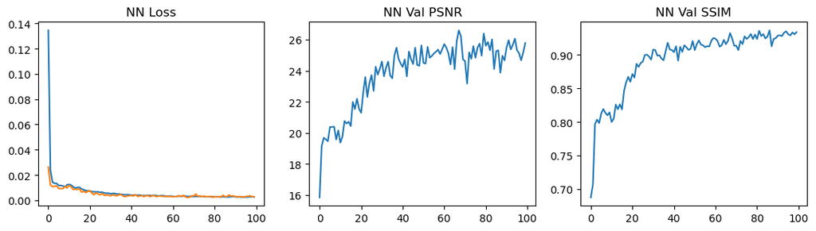

```
==> Training PINN
[PINN] e1: train 2.003e-01 | val 2.846e-02 | PSNR 16.32 | SSIM 0.573
[PINN] e2: train 3.308e-02 | val 2.052e-02 | PSNR 17.65 | SSIM 0.798
[PINN] e3: train 2.472e-02 | val 2.211e-02 | PSNR 17.28 | SSIM 0.754
[PINN] e4: train 1.818e-02 | val 1.445e-02 | PSNR 18.92 | SSIM 0.728
[PINN] e5: train 1.636e-02 | val 1.367e-02 | PSNR 19.10 | SSIM 0.773
[PINN] e6: train 1.594e-02 | val 1.201e-02 | PSNR 19.61 | SSIM 0.775
[PINN] e7: train 1.394e-02 | val 1.376e-02 | PSNR 19.16 | SSIM 0.793
[PINN] e8: train 1.443e-02 | val 1.112e-02 | PSNR 19.87 | SSIM 0.786
[PINN] e9: train 1.242e-02 | val 1.042e-02 | PSNR 20.12 | SSIM 0.809
[PINN] e10: train 1.317e-02 | val 1.171e-02 | PSNR 19.75 | SSIM 0.809
[PINN] e11: train 1.230e-02 | val 9.523e-03 | PSNR 20.45 | SSIM 0.802
[PINN] e12: train 1.114e-02 | val 9.725e-03 | PSNR 20.34 | SSIM 0.809
[PINN] e13: train 1.052e-02 | val 9.191e-03 | PSNR 20.68 | SSIM 0.827
[PINN] e14: train 1.050e-02 | val 9.389e-03 | PSNR 20.53 | SSIM 0.827
[PINN] e15: train 9.363e-03 | val 8.012e-03 | PSNR 21.21 | SSIM 0.836
[PINN] e16: train 9.600e-03 | val 8.404e-03 | PSNR 21.04 | SSIM 0.839
[PINN] e17: train 9.297e-03 | val 7.531e-03 | PSNR 21.42 | SSIM 0.838
[PINN] e18: train 8.582e-03 | val 6.706e-03 | PSNR 21.92 | SSIM 0.856
[PINN] e19: train 8.400e-03 | val 6.884e-03 | PSNR 21.83 | SSIM 0.849
[PINN] e20: train 7.702e-03 | val 6.501e-03 | PSNR 22.06 | SSIM 0.863
[PINN] e21: train 8.597e-03 | val 6.643e-03 | PSNR 21.94 | SSIM 0.858
[PINN] e22: train 8.168e-03 | val 5.641e-03 | PSNR 22.73 | SSIM 0.867
[PINN] e23: train 7.070e-03 | val 4.940e-03 | PSNR 23.24 | SSIM 0.880
[PINN] e24: train 6.806e-03 | val 4.661e-03 | PSNR 23.53 | SSIM 0.890
[PINN] e25: train 6.326e-03 | val 5.178e-03 | PSNR 23.02 | SSIM 0.873
[PINN] e26: train 6.270e-03 | val 4.518e-03 | PSNR 23.66 | SSIM 0.889
[PINN] e27: train 5.828e-03 | val 4.260e-03 | PSNR 23.88 | SSIM 0.897
[PINN] e28: train 5.970e-03 | val 4.086e-03 | PSNR 24.06 | SSIM 0.897
[PINN] e29: train 5.918e-03 | val 4.006e-03 | PSNR 24.17 | SSIM 0.900
[PINN] e30: train 5.485e-03 | val 3.772e-03 | PSNR 24.40 | SSIM 0.900
[PINN] e31: train 5.105e-03 | val 3.997e-03 | PSNR 24.13 | SSIM 0.892
[PINN] e32: train 5.528e-03 | val 4.118e-03 | PSNR 24.14 | SSIM 0.898
[PINN] e33: train 5.291e-03 | val 3.375e-03 | PSNR 24.99 | SSIM 0.907
[PINN] e34: train 4.733e-03 | val 3.074e-03 | PSNR 25.32 | SSIM 0.909
[PINN] e35: train 4.920e-03 | val 3.405e-03 | PSNR 24.89 | SSIM 0.909
[PINN] e36: train 4.950e-03 | val 3.375e-03 | PSNR 24.94 | SSIM 0.905
[PINN] e37: train 4.820e-03 | val 3.552e-03 | PSNR 24.72 | SSIM 0.907
[PINN] e38: train 4.596e-03 | val 3.338e-03 | PSNR 24.92 | SSIM 0.906
[PINN] e39: train 4.157e-03 | val 3.297e-03 | PSNR 25.01 | SSIM 0.910
```

[output cut: 46 more lines]

```
[PINN] e86: train 2.745e-03 | val 4.026e-03 | PSNR 24.48 | SSIM 0.922
[PINN] e87: train 2.674e-03 | val 3.209e-03 | PSNR 25.33 | SSIM 0.925
[PINN] e88: train 2.757e-03 | val 3.116e-03 | PSNR 25.57 | SSIM 0.930
[PINN] e89: train 3.178e-03 | val 4.028e-03 | PSNR 24.60 | SSIM 0.924
[PINN] e90: train 3.099e-03 | val 3.030e-03 | PSNR 25.56 | SSIM 0.932
[PINN] e91: train 2.756e-03 | val 2.302e-03 | PSNR 26.60 | SSIM 0.939
[PINN] e92: train 2.959e-03 | val 2.443e-03 | PSNR 26.47 | SSIM 0.936
[PINN] e93: train 2.723e-03 | val 2.588e-03 | PSNR 26.24 | SSIM 0.936
[PINN] e94: train 2.800e-03 | val 2.684e-03 | PSNR 26.17 | SSIM 0.938
[PINN] e95: train 2.806e-03 | val 2.372e-03 | PSNR 26.54 | SSIM 0.937
[PINN] e96: train 2.754e-03 | val 2.762e-03 | PSNR 25.92 | SSIM 0.932
[PINN] e97: train 2.666e-03 | val 3.799e-03 | PSNR 24.72 | SSIM 0.923
[PINN] e98: train 2.708e-03 | val 3.698e-03 | PSNR 24.89 | SSIM 0.925
[PINN] e99: train 2.577e-03 | val 2.536e-03 | PSNR 26.23 | SSIM 0.934
[PINN] e100: train 2.685e-03 | val 2.901e-03 | PSNR 25.75 | SSIM 0.933
```

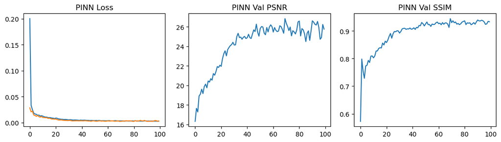

```
==> Training BPINN
[BPINN] e1: train 1.991e-01 | val 3.084e-02 | PSNR 15.95 | SSIM 0.654
[BPINN] e2: train 3.656e-02 | val 1.896e-02 | PSNR 18.00 | SSIM 0.780
[BPINN] e3: train 2.590e-02 | val 2.075e-02 | PSNR 17.55 | SSIM 0.775
[BPINN] e4: train 1.903e-02 | val 1.377e-02 | PSNR 19.20 | SSIM 0.753
[BPINN] e5: train 1.646e-02 | val 1.337e-02 | PSNR 19.22 | SSIM 0.748
[BPINN] e6: train 1.435e-02 | val 1.099e-02 | PSNR 20.13 | SSIM 0.792
[BPINN] e7: train 1.438e-02 | val 1.177e-02 | PSNR 19.77 | SSIM 0.787
[BPINN] e8: train 1.387e-02 | val 1.114e-02 | PSNR 19.98 | SSIM 0.798
[BPINN] e9: train 1.284e-02 | val 1.133e-02 | PSNR 19.90 | SSIM 0.807
[BPINN] e10: train 1.299e-02 | val 1.008e-02 | PSNR 20.39 | SSIM 0.800
[BPINN] e11: train 1.291e-02 | val 1.102e-02 | PSNR 20.03 | SSIM 0.805
[BPINN] e12: train 1.222e-02 | val 1.008e-02 | PSNR 20.45 | SSIM 0.821
[BPINN] e13: train 1.103e-02 | val 1.016e-02 | PSNR 20.48 | SSIM 0.824
[BPINN] e14: train 1.136e-02 | val 1.021e-02 | PSNR 20.22 | SSIM 0.813
[BPINN] e15: train 1.118e-02 | val 9.368e-03 | PSNR 20.66 | SSIM 0.822
[BPINN] e16: train 1.096e-02 | val 9.689e-03 | PSNR 20.57 | SSIM 0.816
[BPINN] e17: train 1.026e-02 | val 9.457e-03 | PSNR 20.63 | SSIM 0.823
[BPINN] e18: train 1.091e-02 | val 8.833e-03 | PSNR 20.92 | SSIM 0.829
[BPINN] e19: train 9.696e-03 | val 7.891e-03 | PSNR 21.40 | SSIM 0.836
[BPINN] e20: train 8.887e-03 | val 6.822e-03 | PSNR 22.06 | SSIM 0.847
[BPINN] e21: train 8.817e-03 | val 7.522e-03 | PSNR 21.67 | SSIM 0.854
[BPINN] e22: train 9.294e-03 | val 7.497e-03 | PSNR 21.64 | SSIM 0.846
[BPINN] e23: train 8.742e-03 | val 6.854e-03 | PSNR 21.99 | SSIM 0.859
[BPINN] e24: train 8.812e-03 | val 6.526e-03 | PSNR 22.22 | SSIM 0.861
[BPINN] e25: train 9.323e-03 | val 7.325e-03 | PSNR 21.84 | SSIM 0.855
[BPINN] e26: train 8.229e-03 | val 5.560e-03 | PSNR 22.95 | SSIM 0.874
[BPINN] e27: train 7.192e-03 | val 5.271e-03 | PSNR 23.21 | SSIM 0.876
[BPINN] e28: train 6.597e-03 | val 6.045e-03 | PSNR 22.66 | SSIM 0.879
[BPINN] e29: train 6.638e-03 | val 4.749e-03 | PSNR 23.63 | SSIM 0.884
[BPINN] e30: train 6.406e-03 | val 5.451e-03 | PSNR 23.08 | SSIM 0.885
[BPINN] e31: train 6.546e-03 | val 4.729e-03 | PSNR 23.67 | SSIM 0.895
[BPINN] e32: train 6.159e-03 | val 5.546e-03 | PSNR 23.04 | SSIM 0.881
[BPINN] e33: train 6.005e-03 | val 5.209e-03 | PSNR 23.23 | SSIM 0.879
[BPINN] e34: train 5.807e-03 | val 4.487e-03 | PSNR 23.92 | SSIM 0.890
[BPINN] e35: train 5.345e-03 | val 4.204e-03 | PSNR 24.20 | SSIM 0.903
[BPINN] e36: train 5.367e-03 | val 4.252e-03 | PSNR 24.15 | SSIM 0.902
[BPINN] e37: train 5.438e-03 | val 4.539e-03 | PSNR 23.95 | SSIM 0.895
[BPINN] e38: train 5.846e-03 | val 5.417e-03 | PSNR 23.27 | SSIM 0.896
[BPINN] e39: train 5.768e-03 | val 4.394e-03 | PSNR 24.04 | SSIM 0.891
```

[output cut: 46 more lines]

```
[BPINN] e86: train 3.095e-03 | val 2.880e-03 | PSNR 26.23 | SSIM 0.934
[BPINN] e87: train 3.056e-03 | val 3.587e-03 | PSNR 25.44 | SSIM 0.936
[BPINN] e88: train 3.215e-03 | val 3.222e-03 | PSNR 25.68 | SSIM 0.931
[BPINN] e89: train 3.144e-03 | val 4.166e-03 | PSNR 24.66 | SSIM 0.923
[BPINN] e90: train 2.940e-03 | val 4.076e-03 | PSNR 24.77 | SSIM 0.927
[BPINN] e91: train 3.287e-03 | val 3.375e-03 | PSNR 25.66 | SSIM 0.938
[BPINN] e92: train 3.277e-03 | val 4.317e-03 | PSNR 24.72 | SSIM 0.930
[BPINN] e93: train 3.178e-03 | val 2.944e-03 | PSNR 26.28 | SSIM 0.945
[BPINN] e94: train 3.106e-03 | val 2.720e-03 | PSNR 26.47 | SSIM 0.940
[BPINN] e95: train 3.307e-03 | val 3.351e-03 | PSNR 25.59 | SSIM 0.932
[BPINN] e96: train 3.132e-03 | val 3.939e-03 | PSNR 25.13 | SSIM 0.935
[BPINN] e97: train 3.013e-03 | val 3.182e-03 | PSNR 25.85 | SSIM 0.934
[BPINN] e98: train 2.853e-03 | val 3.791e-03 | PSNR 25.16 | SSIM 0.933
[BPINN] e99: train 3.345e-03 | val 3.915e-03 | PSNR 25.04 | SSIM 0.933
[BPINN] e100: train 3.046e-03 | val 4.143e-03 | PSNR 24.93 | SSIM 0.934
```

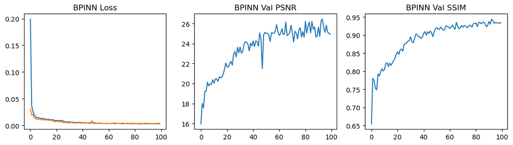

```python
# Set the parameters
out_dir = Path("../output1"); out_dir.mkdir(parents=True, exist_ok=True)
ckpt_dir = Path("../checkpoints1"); ckpt_dir.mkdir(parents=True, exist_ok=True)

EPOCHS=100; LR=1e-3; WD=0.0
ALPHA=1.0; BETA=1e-1; GAMMA=1e-2
PRIOR='tv'  # options: 'tv','h1','lap','rkhs','mean'
NORM_PHYS=True
RKHS_S=1.0; RKHS_LAM=1e-2
BASE_CH=24; DROPOUT=0.1

#### Train the models
def train_model(mode):
    net = UNet(base_ch=BASE_CH, p_drop=DROPOUT).to(device)
    opt = torch.optim.Adam(net.parameters(), lr=LR, weight_decay=WD)
    f_bar = None
    if mode=='BPINN' and PRIOR=='mean':
        acc=[]
        for k,(f_b,_) in enumerate(train_dl):
            acc.append(f_b)
            if k>=6: break
        f_bar = torch.mean(torch.cat(acc,0),0,keepdim=True).to(device)
    hist={'train':[],'val':[],'psnr':[],'ssim':[]}; best=1e9
    for e in range(1, EPOCHS+1):
        tl = train_one_epoch(net, opt, train_dl, mode, ALPHA, BETA, GAMMA, psf, 1, NORM_PHYS, PRIOR, RKHS_S, RKHS_LAM, f_bar)
        vl, vp, vs = evaluate(net, val_dl, mode, ALPHA, BETA, GAMMA, psf, 1, NORM_PHYS, PRIOR, RKHS_S, RKHS_LAM, f_bar)
        hist['train'].append(tl); hist['val'].append(vl); hist['psnr'].append(vp); hist['ssim'].append(vs)
        print(f"[{mode}] e{e}: train {tl:.3e} | val {vl:.3e} | PSNR {vp:.2f} | SSIM {vs:.3f}")
        if vl < best:
            best = vl
            torch.save(net.state_dict(), f"{ckpt_dir}/{mode}_best.pt")
    # curves
    fig, ax = plt.subplots(1,3, figsize=(11,3.2))
    ax[0].plot(hist['train']); ax[0].plot(hist['val']); ax[0].set_title(f"{mode} Loss")
    ax[1].plot(hist['psnr']);  ax[1].set_title(f"{mode} Val PSNR")
    ax[2].plot(hist['ssim']);  ax[2].set_title(f"{mode} Val SSIM")
    plt.tight_layout();
    plt.savefig(f"{out_dir}/Loss_PSNR_SSIM_{mode}.png", dpi=140);
    plt.show()
    return net

nets = {}
for m in ["NN","PINN","BPINN"]:
    print(f"==> Training {m}")
    nets[m] = train_model(m)
```

### Load Trained models, Test them, and Compare

- Load the trained models NN → PINN → BPINN
- Use them for Test data to evaluate performances

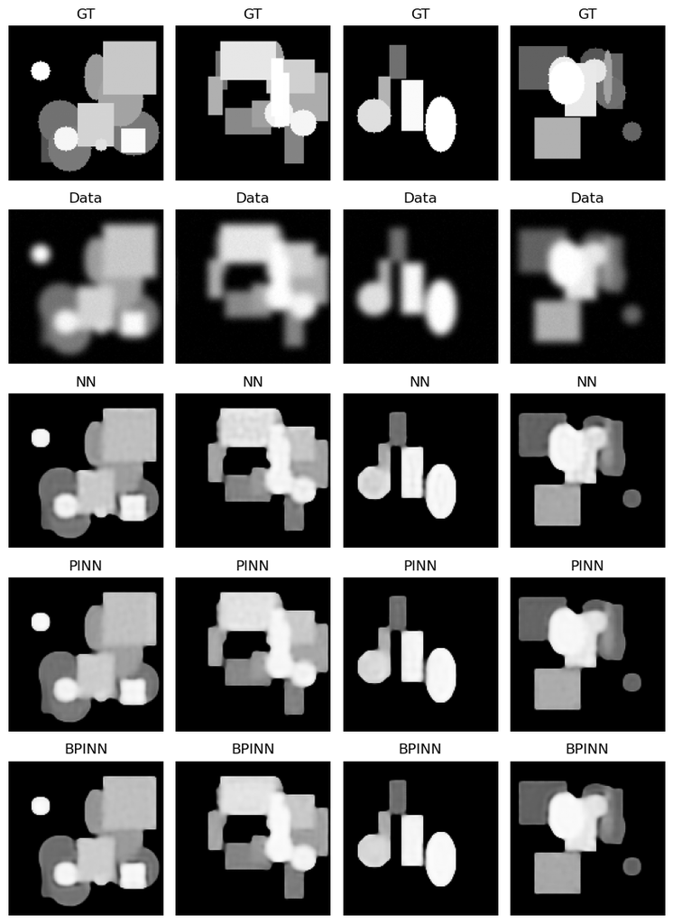

```
Test summary: {
  "NN": {
    "PSNR": 25.466109111785382,
    "SSIM": 0.9191281497478485
  },
  "PINN": {
    "PSNR": 26.89681244446453,
    "SSIM": 0.9473243802785873
  },
  "BPINN": {
    "PSNR": 26.239822621914822,
    "SSIM": 0.9362031817436218
  }
}
```

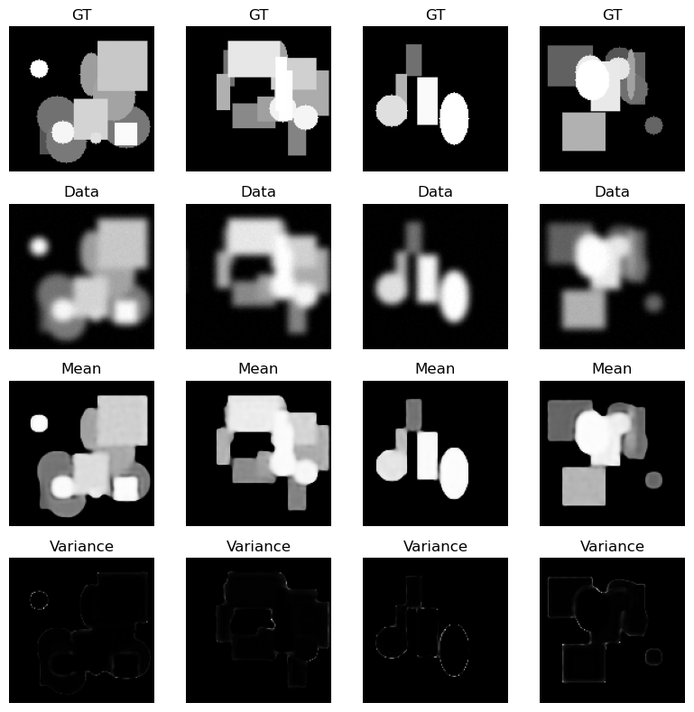

```python
# Comparison & metrics
def load_net(mode):
    net = UNet(base_ch=BASE_CH, p_drop=DROPOUT).to(device)
    net.load_state_dict(torch.load(ckpt_dir/f"{mode}_best.pt", weights_only=True, map_location=device))
    net.eval(); return net

nets = {m: load_net(m) for m in ["NN","PINN","BPINN"]}

f_b, g_b = next(iter(test_dl)); f_b, g_b = f_b.to(device), g_b.to(device)
preds = {m: nets[m](g_b).detach() for m in nets}

n_show = min(4, g_b.shape[0])
fig, axs = plt.subplots(5, n_show, figsize=(2*n_show, 11))
for i in range(n_show):
    axs[0,i].imshow(f_b[i,0].cpu(), vmin=0, vmax=1, cmap='gray'); axs[0,i].set_title("GT"); axs[0,i].axis('off')
    axs[1,i].imshow(g_b[i,0].cpu(), vmin=0, vmax=1, cmap='gray'); axs[1,i].set_title("Data"); axs[1,i].axis('off')
row=2
for m in ["NN","PINN","BPINN"]:
    for i in range(n_show):
        axs[row,i].imshow(preds[m][i,0].cpu(), vmin=0, vmax=1, cmap='gray'); axs[row,i].set_title(m); axs[row,i].axis('off')
    row+=1
plt.savefig(f"{out_dir}/Test_outputs.png", dpi=140);
plt.tight_layout(); plt.show()

summary = {}
for m, net in nets.items():
    psnrs, ssims = [], []
    for f_t, g_t in test_dl:
        f_t, g_t = f_t.to(device), g_t.to(device)
        p = net(g_t).detach()
        psnrs.append(psnr(p, f_t)); ssims.append(ssim_torch(p, f_t))
    summary[m] = {"PSNR": float(np.mean(psnrs)), "SSIM": float(np.mean(ssims))}
print("Test summary:", json.dumps(summary, indent=2))

# UQ
T=16
mean, var = mc_dropout_predict(nets["BPINN"], g_b[:4], T=T)
fig, axs = plt.subplots(4, 4, figsize=(8, 8))
for i in range(4):
    axs[0,i].imshow(f_b[i,0].cpu(), vmin=0, vmax=1, cmap='gray'); axs[0,i].set_title("GT"); axs[0,i].axis('off')
    axs[1,i].imshow(g_b[i,0].cpu(), vmin=0, vmax=1, cmap='gray'); axs[1,i].set_title("Data"); axs[1,i].axis('off')
    axs[2,i].imshow(mean[i,0].cpu(), vmin=0, vmax=1, cmap='gray'); axs[2,i].set_title("Mean"); axs[2,i].axis('off')
    vmax = float(var[i,0].cpu().max().clamp(min=1e-8))
    axs[3,i].imshow(var[i,0].cpu(), vmin=0, vmax=vmax, cmap='gray'); axs[3,i].set_title("Variance"); axs[3,i].axis('off')
plt.tight_layout();
plt.savefig(f"{out_dir}/Test_outputs_BPINN.png", dpi=140);
plt.show()
```

## 8. References

- Rudin, Osher, Fatemi. “Nonlinear Total Variation based noise removal algorithms,” *Physica D* (1992).
- Gal & Ghahramani. “Dropout as a Bayesian Approximation,” *ICML* (2016).
- Kendall & Gal. “What Uncertainties Do We Need in Bayesian Deep Learning for Computer Vision?” *NeurIPS* (2017).
- Raissi, Perdikaris, Karniadakis. “Physics-informed neural networks,” *JCP* (2019).
- Karniadakis et al. “Physics‑informed machine learning,” *Nat. Rev. Phys.* (2021).
- Arridge et al. “Solving inverse problems using data‑driven models,” *Acta Numerica* (2019).

## 9. Repeat with other parameters

```python
#### Set the parameters
out_dir = Path("../output2"); out_dir.mkdir(parents=True, exist_ok=True)
ckpt_dir = Path("../checkpoints2"); ckpt_dir.mkdir(parents=True, exist_ok=True)

EPOCHS=100; LR=1e-3; WD=0.0
ALPHA=1.0; BETA=1e-1; GAMMA=1e-2
PRIOR='lap'  # options: 'tv','h1','lap','rkhs','mean'
NORM_PHYS=True
RKHS_S=1.0; RKHS_LAM=1e-2
BASE_CH=24; DROPOUT=0.1
```

```
==> Training NN
[NN] e1: train 1.423e-01 | val 2.100e-02 | PSNR 16.79 | SSIM 0.428
[NN] e2: train 2.440e-02 | val 1.418e-02 | PSNR 18.50 | SSIM 0.769
[NN] e3: train 1.626e-02 | val 1.274e-02 | PSNR 18.96 | SSIM 0.769
[NN] e4: train 1.354e-02 | val 1.189e-02 | PSNR 19.26 | SSIM 0.782
[NN] e5: train 1.346e-02 | val 1.100e-02 | PSNR 19.59 | SSIM 0.790
[NN] e6: train 1.305e-02 | val 1.090e-02 | PSNR 19.64 | SSIM 0.798
[NN] e7: train 1.164e-02 | val 9.774e-03 | PSNR 20.10 | SSIM 0.806
[NN] e8: train 1.127e-02 | val 9.540e-03 | PSNR 20.24 | SSIM 0.811
[NN] e9: train 1.050e-02 | val 9.331e-03 | PSNR 20.30 | SSIM 0.822
[NN] e10: train 1.050e-02 | val 8.847e-03 | PSNR 20.53 | SSIM 0.813
[NN] e11: train 9.441e-03 | val 8.946e-03 | PSNR 20.51 | SSIM 0.822
[NN] e12: train 9.176e-03 | val 7.904e-03 | PSNR 21.04 | SSIM 0.836
[NN] e13: train 8.785e-03 | val 7.433e-03 | PSNR 21.29 | SSIM 0.837
[NN] e14: train 8.836e-03 | val 7.121e-03 | PSNR 21.48 | SSIM 0.849
[NN] e15: train 8.199e-03 | val 6.648e-03 | PSNR 21.80 | SSIM 0.846
[NN] e16: train 8.064e-03 | val 6.443e-03 | PSNR 21.91 | SSIM 0.847
[NN] e17: train 8.237e-03 | val 7.662e-03 | PSNR 21.17 | SSIM 0.854
[NN] e18: train 7.224e-03 | val 5.704e-03 | PSNR 22.45 | SSIM 0.871
[NN] e19: train 6.702e-03 | val 5.460e-03 | PSNR 22.65 | SSIM 0.871
[NN] e20: train 6.401e-03 | val 4.489e-03 | PSNR 23.51 | SSIM 0.881
[NN] e21: train 6.035e-03 | val 4.433e-03 | PSNR 23.57 | SSIM 0.890
[NN] e22: train 5.386e-03 | val 4.339e-03 | PSNR 23.64 | SSIM 0.894
[NN] e23: train 5.484e-03 | val 4.389e-03 | PSNR 23.58 | SSIM 0.897
[NN] e24: train 5.497e-03 | val 4.694e-03 | PSNR 23.29 | SSIM 0.886
[NN] e25: train 5.177e-03 | val 4.734e-03 | PSNR 23.25 | SSIM 0.890
[NN] e26: train 5.022e-03 | val 3.762e-03 | PSNR 24.26 | SSIM 0.903
[NN] e27: train 4.803e-03 | val 3.407e-03 | PSNR 24.68 | SSIM 0.909
[NN] e28: train 4.473e-03 | val 3.634e-03 | PSNR 24.41 | SSIM 0.899
[NN] e29: train 4.611e-03 | val 3.257e-03 | PSNR 24.89 | SSIM 0.919
[NN] e30: train 4.443e-03 | val 3.216e-03 | PSNR 24.95 | SSIM 0.912
[NN] e31: train 4.202e-03 | val 3.020e-03 | PSNR 25.24 | SSIM 0.914
[NN] e32: train 4.119e-03 | val 2.944e-03 | PSNR 25.35 | SSIM 0.917
[NN] e33: train 3.843e-03 | val 3.026e-03 | PSNR 25.22 | SSIM 0.913
[NN] e34: train 3.937e-03 | val 2.873e-03 | PSNR 25.51 | SSIM 0.919
[NN] e35: train 3.769e-03 | val 2.590e-03 | PSNR 25.88 | SSIM 0.928
[NN] e36: train 3.879e-03 | val 2.875e-03 | PSNR 25.44 | SSIM 0.914
[NN] e37: train 3.796e-03 | val 2.679e-03 | PSNR 25.74 | SSIM 0.921
[NN] e38: train 3.714e-03 | val 3.185e-03 | PSNR 24.98 | SSIM 0.916
[NN] e39: train 3.519e-03 | val 3.010e-03 | PSNR 25.22 | SSIM 0.913
[NN] e40: train 3.484e-03 | val 2.714e-03 | PSNR 25.71 | SSIM 0.929
[NN] e41: train 3.577e-03 | val 2.610e-03 | PSNR 25.88 | SSIM 0.926
[NN] e42: train 3.675e-03 | val 2.888e-03 | PSNR 25.41 | SSIM 0.919
[NN] e43: train 3.541e-03 | val 2.630e-03 | PSNR 25.82 | SSIM 0.929
[NN] e44: train 3.311e-03 | val 2.510e-03 | PSNR 26.01 | SSIM 0.929
[NN] e45: train 3.285e-03 | val 2.592e-03 | PSNR 25.87 | SSIM 0.924
[NN] e46: train 3.533e-03 | val 3.125e-03 | PSNR 25.11 | SSIM 0.917
[NN] e47: train 3.257e-03 | val 2.911e-03 | PSNR 25.36 | SSIM 0.918
[NN] e48: train 3.286e-03 | val 2.878e-03 | PSNR 25.46 | SSIM 0.915
[NN] e49: train 3.310e-03 | val 2.410e-03 | PSNR 26.23 | SSIM 0.931
[NN] e50: train 3.184e-03 | val 2.643e-03 | PSNR 25.78 | SSIM 0.932
```

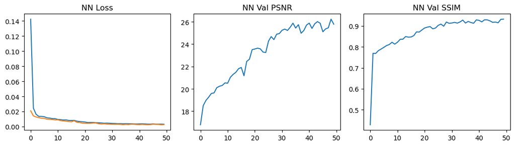

```
==> Training PINN
[PINN] e1: train 1.901e-01 | val 6.461e-02 | PSNR 13.14 | SSIM 0.287
[PINN] e2: train 3.807e-02 | val 2.356e-02 | PSNR 17.05 | SSIM 0.791
[PINN] e3: train 2.019e-02 | val 1.350e-02 | PSNR 19.25 | SSIM 0.763
[PINN] e4: train 1.890e-02 | val 1.524e-02 | PSNR 18.74 | SSIM 0.721
[PINN] e5: train 1.628e-02 | val 1.506e-02 | PSNR 18.74 | SSIM 0.675
[PINN] e6: train 1.493e-02 | val 1.248e-02 | PSNR 19.48 | SSIM 0.643
[PINN] e7: train 1.477e-02 | val 1.218e-02 | PSNR 19.53 | SSIM 0.721
[PINN] e8: train 1.426e-02 | val 1.137e-02 | PSNR 19.76 | SSIM 0.733
[PINN] e9: train 1.254e-02 | val 1.062e-02 | PSNR 19.99 | SSIM 0.785
[PINN] e10: train 1.190e-02 | val 9.514e-03 | PSNR 20.44 | SSIM 0.796
[PINN] e11: train 1.176e-02 | val 8.507e-03 | PSNR 20.96 | SSIM 0.808
[PINN] e12: train 1.041e-02 | val 8.872e-03 | PSNR 20.80 | SSIM 0.809
[PINN] e13: train 9.649e-03 | val 7.943e-03 | PSNR 21.20 | SSIM 0.826
[PINN] e14: train 9.227e-03 | val 7.246e-03 | PSNR 21.60 | SSIM 0.827
[PINN] e15: train 8.655e-03 | val 6.973e-03 | PSNR 21.80 | SSIM 0.849
[PINN] e16: train 8.784e-03 | val 6.496e-03 | PSNR 22.16 | SSIM 0.857
[PINN] e17: train 7.959e-03 | val 6.461e-03 | PSNR 22.17 | SSIM 0.867
[PINN] e18: train 8.201e-03 | val 5.779e-03 | PSNR 22.61 | SSIM 0.879
[PINN] e19: train 8.789e-03 | val 6.372e-03 | PSNR 22.18 | SSIM 0.854
[PINN] e20: train 8.312e-03 | val 5.892e-03 | PSNR 22.57 | SSIM 0.868
[PINN] e21: train 7.450e-03 | val 5.626e-03 | PSNR 22.75 | SSIM 0.880
[PINN] e22: train 7.362e-03 | val 4.777e-03 | PSNR 23.47 | SSIM 0.891
[PINN] e23: train 7.321e-03 | val 5.673e-03 | PSNR 22.74 | SSIM 0.877
[PINN] e24: train 7.525e-03 | val 6.057e-03 | PSNR 22.35 | SSIM 0.869
[PINN] e25: train 7.030e-03 | val 5.087e-03 | PSNR 23.10 | SSIM 0.882
[PINN] e26: train 6.759e-03 | val 4.871e-03 | PSNR 23.39 | SSIM 0.893
[PINN] e27: train 6.873e-03 | val 4.933e-03 | PSNR 23.34 | SSIM 0.888
[PINN] e28: train 6.364e-03 | val 4.265e-03 | PSNR 23.87 | SSIM 0.894
[PINN] e29: train 6.404e-03 | val 4.871e-03 | PSNR 23.33 | SSIM 0.882
[PINN] e30: train 6.250e-03 | val 4.261e-03 | PSNR 23.89 | SSIM 0.902
[PINN] e31: train 5.861e-03 | val 4.698e-03 | PSNR 23.44 | SSIM 0.893
[PINN] e32: train 5.531e-03 | val 3.973e-03 | PSNR 24.23 | SSIM 0.900
[PINN] e33: train 5.874e-03 | val 3.825e-03 | PSNR 24.43 | SSIM 0.909
[PINN] e34: train 5.728e-03 | val 3.724e-03 | PSNR 24.47 | SSIM 0.915
[PINN] e35: train 5.240e-03 | val 4.003e-03 | PSNR 24.14 | SSIM 0.896
[PINN] e36: train 5.231e-03 | val 3.809e-03 | PSNR 24.39 | SSIM 0.905
[PINN] e37: train 5.758e-03 | val 3.879e-03 | PSNR 24.31 | SSIM 0.899
[PINN] e38: train 5.230e-03 | val 3.785e-03 | PSNR 24.51 | SSIM 0.909
[PINN] e39: train 5.241e-03 | val 4.205e-03 | PSNR 24.13 | SSIM 0.905
[PINN] e40: train 5.352e-03 | val 4.250e-03 | PSNR 23.93 | SSIM 0.901
[PINN] e41: train 5.113e-03 | val 3.720e-03 | PSNR 24.53 | SSIM 0.906
[PINN] e42: train 5.394e-03 | val 3.662e-03 | PSNR 24.57 | SSIM 0.906
[PINN] e43: train 5.082e-03 | val 3.360e-03 | PSNR 24.94 | SSIM 0.911
[PINN] e44: train 4.681e-03 | val 3.062e-03 | PSNR 25.32 | SSIM 0.913
[PINN] e45: train 4.127e-03 | val 3.289e-03 | PSNR 24.98 | SSIM 0.910
[PINN] e46: train 4.384e-03 | val 3.314e-03 | PSNR 24.99 | SSIM 0.911
[PINN] e47: train 4.291e-03 | val 3.153e-03 | PSNR 25.16 | SSIM 0.916
[PINN] e48: train 4.472e-03 | val 3.564e-03 | PSNR 24.70 | SSIM 0.907
[PINN] e49: train 4.227e-03 | val 3.477e-03 | PSNR 24.80 | SSIM 0.904
[PINN] e50: train 4.192e-03 | val 3.080e-03 | PSNR 25.28 | SSIM 0.918
```

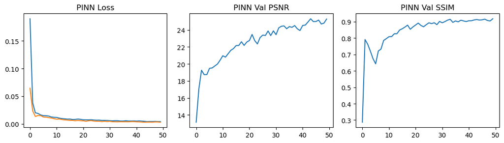

```
==> Training BPINN
[BPINN] e1: train 2.711e-01 | val 1.361e-01 | PSNR 10.21 | SSIM 0.208
[BPINN] e2: train 5.557e-02 | val 2.895e-02 | PSNR 16.26 | SSIM 0.784
[BPINN] e3: train 2.608e-02 | val 1.508e-02 | PSNR 18.63 | SSIM 0.607
[BPINN] e4: train 1.869e-02 | val 1.354e-02 | PSNR 19.17 | SSIM 0.734
[BPINN] e5: train 1.645e-02 | val 1.354e-02 | PSNR 19.06 | SSIM 0.718
[BPINN] e6: train 1.532e-02 | val 1.146e-02 | PSNR 19.84 | SSIM 0.795
[BPINN] e7: train 1.327e-02 | val 1.195e-02 | PSNR 19.69 | SSIM 0.785
[BPINN] e8: train 1.310e-02 | val 1.088e-02 | PSNR 20.08 | SSIM 0.810
[BPINN] e9: train 1.286e-02 | val 9.801e-03 | PSNR 20.44 | SSIM 0.804
[BPINN] e10: train 1.204e-02 | val 1.032e-02 | PSNR 20.23 | SSIM 0.803
[BPINN] e11: train 1.160e-02 | val 9.641e-03 | PSNR 20.50 | SSIM 0.808
[BPINN] e12: train 1.114e-02 | val 8.703e-03 | PSNR 20.97 | SSIM 0.824
[BPINN] e13: train 1.047e-02 | val 8.603e-03 | PSNR 21.04 | SSIM 0.836
[BPINN] e14: train 1.071e-02 | val 8.559e-03 | PSNR 21.03 | SSIM 0.828
[BPINN] e15: train 9.730e-03 | val 8.247e-03 | PSNR 21.20 | SSIM 0.832
[BPINN] e16: train 8.702e-03 | val 8.630e-03 | PSNR 21.21 | SSIM 0.849
[BPINN] e17: train 8.474e-03 | val 7.120e-03 | PSNR 21.84 | SSIM 0.857
[BPINN] e18: train 8.025e-03 | val 6.723e-03 | PSNR 22.04 | SSIM 0.846
[BPINN] e19: train 7.554e-03 | val 6.207e-03 | PSNR 22.40 | SSIM 0.871
[BPINN] e20: train 7.163e-03 | val 5.908e-03 | PSNR 22.65 | SSIM 0.870
[BPINN] e21: train 6.843e-03 | val 5.338e-03 | PSNR 23.14 | SSIM 0.869
[BPINN] e22: train 6.416e-03 | val 5.099e-03 | PSNR 23.31 | SSIM 0.877
[BPINN] e23: train 6.583e-03 | val 5.760e-03 | PSNR 22.82 | SSIM 0.882
[BPINN] e24: train 6.710e-03 | val 4.807e-03 | PSNR 23.59 | SSIM 0.886
[BPINN] e25: train 6.380e-03 | val 5.016e-03 | PSNR 23.51 | SSIM 0.892
[BPINN] e26: train 5.738e-03 | val 5.402e-03 | PSNR 23.33 | SSIM 0.894
[BPINN] e27: train 5.875e-03 | val 4.950e-03 | PSNR 23.44 | SSIM 0.885
[BPINN] e28: train 5.472e-03 | val 4.489e-03 | PSNR 23.95 | SSIM 0.897
[BPINN] e29: train 5.636e-03 | val 4.669e-03 | PSNR 23.75 | SSIM 0.891
[BPINN] e30: train 5.345e-03 | val 4.116e-03 | PSNR 24.39 | SSIM 0.904
[BPINN] e31: train 4.764e-03 | val 4.156e-03 | PSNR 24.35 | SSIM 0.908
[BPINN] e32: train 5.433e-03 | val 5.318e-03 | PSNR 23.33 | SSIM 0.894
[BPINN] e33: train 4.894e-03 | val 5.140e-03 | PSNR 23.54 | SSIM 0.893
[BPINN] e34: train 4.899e-03 | val 4.541e-03 | PSNR 24.11 | SSIM 0.900
[BPINN] e35: train 4.588e-03 | val 3.853e-03 | PSNR 24.69 | SSIM 0.911
[BPINN] e36: train 4.586e-03 | val 3.980e-03 | PSNR 24.73 | SSIM 0.916
[BPINN] e37: train 5.139e-03 | val 7.175e-03 | PSNR 22.33 | SSIM 0.893
[BPINN] e38: train 5.483e-03 | val 3.822e-03 | PSNR 24.71 | SSIM 0.908
[BPINN] e39: train 4.833e-03 | val 3.404e-03 | PSNR 25.27 | SSIM 0.914
[BPINN] e40: train 4.619e-03 | val 4.039e-03 | PSNR 24.57 | SSIM 0.915
[BPINN] e41: train 4.421e-03 | val 4.716e-03 | PSNR 24.05 | SSIM 0.912
[BPINN] e42: train 4.187e-03 | val 4.349e-03 | PSNR 24.33 | SSIM 0.912
[BPINN] e43: train 4.274e-03 | val 4.282e-03 | PSNR 24.55 | SSIM 0.922
[BPINN] e44: train 4.378e-03 | val 5.675e-03 | PSNR 23.32 | SSIM 0.907
[BPINN] e45: train 4.643e-03 | val 3.340e-03 | PSNR 25.32 | SSIM 0.919
[BPINN] e46: train 5.175e-03 | val 3.614e-03 | PSNR 25.10 | SSIM 0.915
[BPINN] e47: train 4.268e-03 | val 3.764e-03 | PSNR 24.99 | SSIM 0.925
[BPINN] e48: train 4.090e-03 | val 3.116e-03 | PSNR 25.78 | SSIM 0.927
[BPINN] e49: train 4.058e-03 | val 4.600e-03 | PSNR 24.13 | SSIM 0.913
[BPINN] e50: train 3.605e-03 | val 4.444e-03 | PSNR 24.40 | SSIM 0.919
```

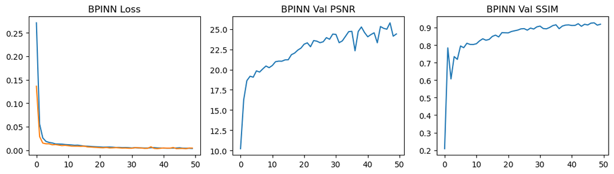

```python
# Set the parameters

EPOCHS=50; LR=1e-3; WD=0.0
ALPHA=1.0; BETA=1e-1; GAMMA=1e-2
PRIOR='tv'  # options: 'tv','h1','lap','rkhs','mean'
NORM_PHYS=True
RKHS_S=1.0; RKHS_LAM=1e-2
BASE_CH=24; DROPOUT=0.1

#### Train the models
def train_model(mode):
    net = UNet(base_ch=BASE_CH, p_drop=DROPOUT).to(device)
    opt = torch.optim.Adam(net.parameters(), lr=LR, weight_decay=WD)
    f_bar = None
    if mode=='BPINN' and PRIOR=='mean':
        acc=[]
        for k,(f_b,_) in enumerate(train_dl):
            acc.append(f_b)
            if k>=6: break
        f_bar = torch.mean(torch.cat(acc,0),0,keepdim=True).to(device)
    hist={'train':[],'val':[],'psnr':[],'ssim':[]}; best=1e9
    for e in range(1, EPOCHS+1):
        tl = train_one_epoch(net, opt, train_dl, mode, ALPHA, BETA, GAMMA, psf, 1, NORM_PHYS, PRIOR, RKHS_S, RKHS_LAM, f_bar)
        vl, vp, vs = evaluate(net, val_dl, mode, ALPHA, BETA, GAMMA, psf, 1, NORM_PHYS, PRIOR, RKHS_S, RKHS_LAM, f_bar)
        hist['train'].append(tl); hist['val'].append(vl); hist['psnr'].append(vp); hist['ssim'].append(vs)
        print(f"[{mode}] e{e}: train {tl:.3e} | val {vl:.3e} | PSNR {vp:.2f} | SSIM {vs:.3f}")
        if vl < best:
            best = vl
            torch.save(net.state_dict(), f"{ckpt_dir}/{mode}_best.pt")
    # curves
    fig, ax = plt.subplots(1,3, figsize=(11,3.2))
    ax[0].plot(hist['train']); ax[0].plot(hist['val']); ax[0].set_title(f"{mode} Loss")
    ax[1].plot(hist['psnr']);  ax[1].set_title(f"{mode} Val PSNR")
    ax[2].plot(hist['ssim']);  ax[2].set_title(f"{mode} Val SSIM")
    plt.tight_layout();
    plt.savefig(f"{out_dir}/Loss_PSNR_SSIM_{mode}.png", dpi=140);
    plt.show()
    return net

nets = {}
for m in ["NN","PINN","BPINN"]:
    print(f"==> Training {m}")
    nets[m] = train_model(m)
```

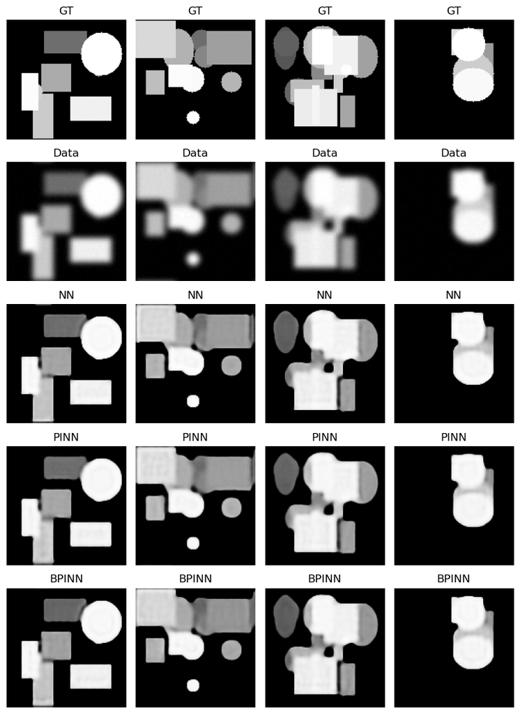

```
Test summary: {
  "NN": {
    "PSNR": 25.86850684797281,
    "SSIM": 0.9272705763578415
  },
  "PINN": {
    "PSNR": 24.879275452484258,
    "SSIM": 0.9031964391469955
  },
  "BPINN": {
    "PSNR": 25.773773999674603,
    "SSIM": 0.9237368553876877
  }
}
```

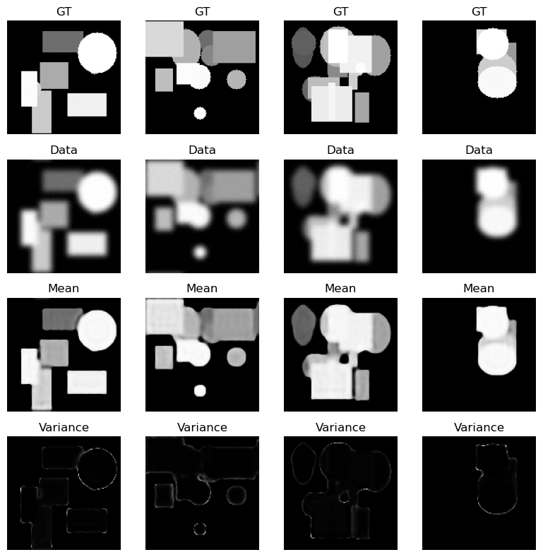

```python
# Comparison & metrics
def load_net(mode):
    net = UNet(base_ch=BASE_CH, p_drop=DROPOUT).to(device)
    net.load_state_dict(torch.load(ckpt_dir/f"{mode}_best.pt", weights_only=True, map_location=device))
    net.eval(); return net

nets = {m: load_net(m) for m in ["NN","PINN","BPINN"]}

f_b, g_b = next(iter(test_dl)); f_b, g_b = f_b.to(device), g_b.to(device)
preds = {m: nets[m](g_b).detach() for m in nets}

n_show = min(4, g_b.shape[0])
fig, axs = plt.subplots(5, n_show, figsize=(2*n_show, 11))
for i in range(n_show):
    axs[0,i].imshow(f_b[i,0].cpu(), vmin=0, vmax=1, cmap='gray'); axs[0,i].set_title("GT"); axs[0,i].axis('off')
    axs[1,i].imshow(g_b[i,0].cpu(), vmin=0, vmax=1, cmap='gray'); axs[1,i].set_title("Data"); axs[1,i].axis('off')
row=2
for m in ["NN","PINN","BPINN"]:
    for i in range(n_show):
        axs[row,i].imshow(preds[m][i,0].cpu(), vmin=0, vmax=1, cmap='gray'); axs[row,i].set_title(m); axs[row,i].axis('off')
    row+=1
plt.tight_layout();
plt.savefig(f"{out_dir}/Test_outputs.png", dpi=140);
plt.show()

summary = {}
for m, net in nets.items():
    psnrs, ssims = [], []
    for f_t, g_t in test_dl:
        f_t, g_t = f_t.to(device), g_t.to(device)
        p = net(g_t).detach()
        psnrs.append(psnr(p, f_t)); ssims.append(ssim_torch(p, f_t))
    summary[m] = {"PSNR": float(np.mean(psnrs)), "SSIM": float(np.mean(ssims))}
print("Test summary:", json.dumps(summary, indent=2))

# UQ
T=16
mean, var = mc_dropout_predict(nets["BPINN"], g_b[:4], T=T)
fig, axs = plt.subplots(4, 4, figsize=(8, 8))
for i in range(4):
    axs[0,i].imshow(f_b[i,0].cpu(), vmin=0, vmax=1, cmap='gray'); axs[0,i].set_title("GT"); axs[0,i].axis('off')
    axs[1,i].imshow(g_b[i,0].cpu(), vmin=0, vmax=1, cmap='gray'); axs[1,i].set_title("Data"); axs[1,i].axis('off')
    axs[2,i].imshow(mean[i,0].cpu(), vmin=0, vmax=1, cmap='gray'); axs[2,i].set_title("Mean"); axs[2,i].axis('off')
    vmax = float(var[i,0].cpu().max().clamp(min=1e-8))
    axs[3,i].imshow(var[i,0].cpu(), vmin=0, vmax=vmax, cmap='gray'); axs[3,i].set_title("Variance"); axs[3,i].axis('off')
plt.tight_layout();
plt.savefig(f"{out_dir}/Test_outputs_BPINN.png", dpi=140);
plt.show()
```